# Chapter 3

# Libraries

```r
library(HH)
library(nlme)
library(dplyr)
library(lmtest)
library(lme4)
library(ggplot2)
```

# Kukupa Dataset

```r
kukupa <- read.csv("/Users/jasonchan/MSTAT/STAT6014_Advanced_Stat_Model/data/kukupa.csv")

kukupa$station <- as.factor(kukupa$station)
kukupa$year <- kukupa$year - 6.5

str(kukupa)
```

```
'data.frame':   120 obs. of  5 variables:
 $ obs     : int  101 102 103 104 105 106 107 108 109 110 ...
 $ station : Factor w/ 10 levels "81","82","83",..: 1 1 1 1 1 1 1 1 1 1 ...
 $ cal_year: int  1995 1996 1997 1998 1999 2000 2001 2002 2003 2004 ...
 $ year    : num  -5.5 -4.5 -3.5 -2.5 -1.5 -0.5 0.5 1.5 2.5 3.5 ...
 $ acount  : num  0 0.408 0.408 0.707 0.866 ...
```

- balanced data, equal number of observations ($n_i = 12$) for each of the 10 stations
- longitudinal data, recorded over time

## Multiple Linear Regression

- First attempt is normal to try MLR
- 10 models, one for each station
- Use reference coding

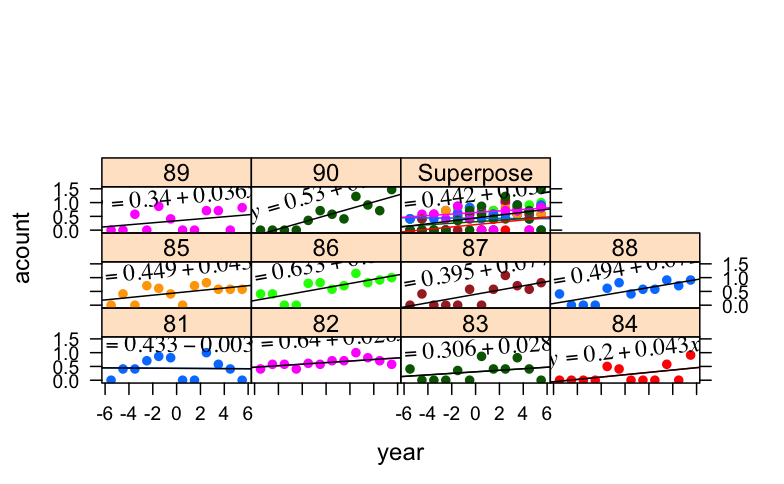

```r
ancovaplot(acount~year*station, data = kukupa, pch = 16,
           layout = c(3,4)) +
layer(panel.ablineq(lm(y ~ x), rot = TRUE, at = 0.5, pos = 3))
```

- Kukupa numbers are **increasing over time** at most observation stations
- Subtantial variability among stations, especially their slopes

### Problems

- Time series data, dependent over time. MLR assume all random errors are independent
- The 10 regressions are only relevant for each selected station but not the **entire study area**

### Solution

- Treat the 10 stations are a random sample from the whole area
- Introduce some random effects for intercept and slope for each station

For each station $i$ and each year $x_j$:

$$y_{ij} = \beta_0 + \beta_1x_j + (a_i+b_ix_j) + \epsilon_{ij}$$

where $\beta_0, \beta_1$ are fixed effects, $a_i, b_i$ are random effects

## Linear Mixed Effect Model (LME)

```r
fit <- lme(acount~year, data = kukupa, random = ~year|station)
fit
```

```
Linear mixed-effects model fit by REML
  Data: kukupa
  Log-restricted-likelihood: -32.87337
  Fixed: acount ~ year
(Intercept)        year
 0.44201167  0.05246734

Random effects:
 Formula: ~year | station
 Structure: General positive-definite, Log-Cholesky parametrization
            StdDev     Corr
(Intercept) 0.11318894 (Intr)
year        0.02610594 0.52
Residual    0.28411156

Number of Observations: 120
Number of Groups: 10
```

### Interpretation

Population average regression line

- $E(y)=0.44201167 + 0.05246734x$
- $\hat{\sigma}_a = 0.11318894$
- $\hat{\sigma}_b = 0.02610594$
- $\hat{\sigma}_e = 0.28411156$
- $\hat{\rho}_{ab} = 0.52$
- A high $\hat{\sigma}_a$ mean large variation in intercepts of all stations
- A high $\hat{\sigma}_b$ mean large variation in slopes of all stations

## Model Comparison

- **Model 1**: No random effects with AR(1) errors
- **Model 2**: Random intercepts with independent errors
- **Model 3**: Random slopes with independent errors
- **Model 4**: Independent intercept and slope with independent errors
- **Model 5**: Correlated intercept and slope with independent errors

### Model 1

No random effects with AR(1) errors

$$y_i = X_i\beta+ \epsilon_i, \epsilon_i \sim AR(1)$$

- use `gls()` instead of `lme()` as no random effects

```r
# Fit linear mixed effects model (Model 1),
# with no random effects, and AR(1) errors
fit1 <- gls(acount~year, data = kukupa,
            correlation = corAR1(form = ~1|station))
fit1
```

```
Generalized least squares fit by REML
  Model: acount ~ year
  Data: kukupa
  Log-restricted-likelihood: -34.68285

Coefficients:
(Intercept)        year
 0.44172107  0.05207381

Correlation Structure: AR(1)
 Formula: ~1 | station
 Parameter estimate(s):
      Phi
0.2311002
Degrees of freedom: 120 total; 118 residual
Residual standard error: 0.3174795
```

### Model 2

Random intercepts with independent errors

$$y_i = X_i\beta+Z_ib_i + \epsilon_i$$

$$b_i=(a_i, 0)', S_i=\sigma^2_eI_n$$

```r
# Fit linear mixed effects model (Model 2),
# with random intercept and fixed slope for each station
fit2 <- lme(acount~year, data = kukupa, random = ~1|station)
fit2
```

```
Linear mixed-effects model fit by REML
  Data: kukupa
  Log-restricted-likelihood: -34.94883
  Fixed: acount ~ year
(Intercept)        year
 0.44201167  0.05246734

Random effects:
 Formula: ~1 | station
        (Intercept)  Residual
StdDev:   0.1101892 0.2979365

Number of Observations: 120
Number of Groups: 10
```

### Model 3

Random slopes with independent errors

$$y_i = X_iB_i + Z_ib_i + \epsilon_i$$

$$b_i=(0, b_i)', S_i=\sigma^2_eI_n$$

```r
# Fit linear mixed effects model (Model 3),
# with fixed intercept and random slope for each station
fit3 <- lme(acount~year, data = kukupa, random = ~0+year|station)
fit3
```

```
Linear mixed-effects model fit by REML
  Data: kukupa
  Log-restricted-likelihood: -36.49464
  Fixed: acount ~ year
(Intercept)        year
 0.44201167  0.05246734

Random effects:
 Formula: ~0 + year | station
              year  Residual
StdDev: 0.02434636 0.3056364

Number of Observations: 120
Number of Groups: 10
```

### Model 4

Independent intercept and slope with independent errors

$$y_i = X_iB_i + Z_ib_i + \epsilon_i$$

$$D_i = \begin{pmatrix}
\sigma^2_a & 0 \\
0 & \sigma^2_b
\end{pmatrix}$$

$$S_i=\sigma^2_eI_n$$

- use of `pdDiag()` to indicate independent random slopes and intercept

```r
# Fit linear mixed effects model (Model 4),
# with independent random intercept slope for each station
fit4 <- lme(acount~year, data = kukupa,
            random = list(station = pdDiag(~year)))
fit4
```

```
Linear mixed-effects model fit by REML
  Data: kukupa
  Log-restricted-likelihood: -33.33286
  Fixed: acount ~ year
(Intercept)        year
 0.44201167  0.05246734

Random effects:
 Formula: ~year | station
 Structure: Diagonal
        (Intercept)       year  Residual
StdDev:   0.1131887 0.02610595 0.2841116

Number of Observations: 120
Number of Groups: 10
```

### Mdoel 5 (Full Model)

Correlated intercept and slope with independent errors

$$y_i = X_iB_i + Z_ib_i + \epsilon_i$$

$$D_i = \begin{pmatrix}
\sigma^2_a & \sigma^2_{ab} \\
\sigma^2_{ab} & \sigma^2_b
\end{pmatrix}$$

$$S_i=\sigma^2_eI_n$$

```r
# Fit linear mixed effects model (Model5),
# with correlated random intercept and slope for each station
fit5 <- lme(acount~year, data = kukupa, random = ~year|station)
fit5
```

```
Linear mixed-effects model fit by REML
  Data: kukupa
  Log-restricted-likelihood: -32.87337
  Fixed: acount ~ year
(Intercept)        year
 0.44201167  0.05246734

Random effects:
 Formula: ~year | station
 Structure: General positive-definite, Log-Cholesky parametrization
            StdDev     Corr
(Intercept) 0.11318894 (Intr)
year        0.02610594 0.52
Residual    0.28411156

Number of Observations: 120
Number of Groups: 10
```

## AIC Comparison

```r
comp <- data.frame(model1=AIC(fit1), model2=AIC(fit2),model3=AIC(fit3), model4=AIC(fit4), model5=AIC(fit5))

data.frame(t(comp))
```

|  | t.comp. |
| --- | --- |
| model1 | 77.36569 |
| model2 | 77.89766 |
| model3 | 80.98928 |
| model4 | 76.66572 |
| model5 | 77.74675 |

- Model 4 is the best here

## LR Test

- Model 4 vs model 5

```r
lrtest(fit5, fit4)
```

```
Likelihood ratio test

Model 1: acount ~ year
Model 2: acount ~ year
  #Df  LogLik Df Chisq Pr(>Chisq)
1   6 -32.873
2   5 -33.333 -1 0.919     0.3377
```

- Model 4 is not significantly worse than 5 in terms of LR

## Significance Test for Fixed Effects

- Use maximum likelihood (ML) as estimation method
- Doesn’t eliminate the fixed effects unlike the restricted LRT
- Restricted LRT must have the same fixed effects
- For GLMM, tests for fixed effects is often not primary interest, when random effects are present

```r
# Fit linear mixed effects model (Final Model) using ML,
# and then perform LRT on fixed effect of year
finalML <- lme(acount~year, data = kukupa, method = 'ML',
             random = list(station = pdDiag(~year)))
drop1(finalML, test="Chisq")
```

```
Single term deletions

Model:
acount ~ year
       Df    AIC    LRT  Pr(>Chi)
<none>    65.006
year    1 75.404 12.398 0.0004299 ***
---
Signif. codes:  0 ‘***’ 0.001 ‘**’ 0.01 ‘*’ 0.05 ‘.’ 0.1 ‘ ’ 1
```

# Epileptic Seizure Data

Demonstrating Generalized Linear Mixed Models (GLIMM)

```r
epilepsy <- read.csv("/Users/jasonchan/MSTAT/STAT6014_Advanced_Stat_Model/data/epilepsy.csv")

epilepsy$patient <- as.factor(epilepsy$patient)
epilepsy$lage <- log(epilepsy$age)
epilepsy$lbase <- log(epilepsy$baseline/4)

epilepsy
```

| patient | seizure | period | treat | baseline | age | lage | lbase |
| --- | --- | --- | --- | --- | --- | --- | --- |
| 104 | 5 | 1 | 0 | 11 | 31 | 3.433987 | 1.0116009 |
| 104 | 3 | 2 | 0 | 11 | 31 | 3.433987 | 1.0116009 |
| 104 | 3 | 3 | 0 | 11 | 31 | 3.433987 | 1.0116009 |
| 104 | 3 | 4 | 0 | 11 | 31 | 3.433987 | 1.0116009 |
| 106 | 3 | 1 | 0 | 11 | 30 | 3.401197 | 1.0116009 |
| 106 | 5 | 2 | 0 | 11 | 30 | 3.401197 | 1.0116009 |
| 106 | 3 | 3 | 0 | 11 | 30 | 3.401197 | 1.0116009 |
| 106 | 3 | 4 | 0 | 11 | 30 | 3.401197 | 1.0116009 |
| 107 | 2 | 1 | 0 | 6 | 25 | 3.218876 | 0.4054651 |
| 107 | 4 | 2 | 0 | 6 | 25 | 3.218876 | 0.4054651 |

[output cut: 218 more lines]

- Fixed effects: `treat, period, lage, lbase`
- Random effects: intercept, (slope for) `period`
- Subject for data cluster: `patient` (random sample)
- Four potential GLIMMs are fitted using Laplace approximation, and Poisson response distribution with `log-link`:
  - Model 1: Random intercepts
  - Model 2: Random slopes
  - Model 3: Independent random intercepts and slopes
  - Model 4: Correlated random intercepts and slopes

## Model Comparison

### Model 1: Random intercepts

```r
fit1 <- glmer(seizure~treat+period+lage+lbase+(1|patient), data=epilepsy, family = "poisson")
summary(fit1)
```

```
Generalized linear mixed model fit by maximum likelihood (Laplace
  Approximation) [glmerMod]
 Family: poisson  ( log )
Formula: seizure ~ treat + period + lage + lbase + (1 | patient)
   Data: epilepsy

     AIC      BIC   logLik deviance df.resid
  1219.0   1239.6   -603.5   1207.0      222

Scaled residuals:
    Min      1Q  Median      3Q     Max
-3.2880 -0.7656 -0.0931  0.5764  3.9115

Random effects:
 Groups  Name        Variance Std.Dev.
 patient (Intercept) 0.2258   0.4752
Number of obs: 228, groups:  patient, 57

Fixed effects:
            Estimate Std. Error z value Pr(>|z|)
(Intercept) -0.90471    1.12238  -0.806   0.4202
treat       -0.30545    0.14308  -2.135   0.0328 *
period      -0.06626    0.02296  -2.886   0.0039 **
lage         0.36274    0.32158   1.128   0.2593
lbase        0.91719    0.10140   9.045   <2e-16 ***
---
Signif. codes:  0 ‘***’ 0.001 ‘**’ 0.01 ‘*’ 0.05 ‘.’ 0.1 ‘ ’ 1

Correlation of Fixed Effects:
       (Intr) treat  period lage
treat  -0.163
period -0.049  0.000
lage   -0.982  0.107  0.000
lbase  -0.300 -0.023  0.000  0.146
```

### Model 2: Random Slopes (no intercept)

```r
fit2 <- glmer(seizure~treat+period+lage+lbase+(period-1|patient), data=epilepsy, family = "poisson")
summary(fit2)
```

```
Generalized linear mixed model fit by maximum likelihood (Laplace
  Approximation) [glmerMod]
 Family: poisson  ( log )
Formula:
seizure ~ treat + period + lage + lbase + (period - 1 | patient)
   Data: epilepsy

     AIC      BIC   logLik deviance df.resid
  1261.7   1282.3   -624.8   1249.7      222

Scaled residuals:
    Min      1Q  Median      3Q     Max
-2.4528 -0.8672 -0.1201  0.6459  5.0926

Random effects:
 Groups  Name   Variance Std.Dev.
 patient period 0.02787  0.1669
Number of obs: 228, groups:  patient, 57

Fixed effects:
            Estimate Std. Error z value Pr(>|z|)
(Intercept) -2.38332    0.76951  -3.097 0.001954 **
treat       -0.23379    0.09624  -2.429 0.015128 *
period      -0.12353    0.03468  -3.562 0.000367 ***
lage         0.83379    0.21650   3.851 0.000118 ***
lbase        0.93547    0.06809  13.739  < 2e-16 ***
---
Signif. codes:  0 ‘***’ 0.001 ‘**’ 0.01 ‘*’ 0.05 ‘.’ 0.1 ‘ ’ 1

Correlation of Fixed Effects:
       (Intr) treat  period lage
treat  -0.247
period -0.124 -0.038
lage   -0.976  0.183  0.029
lbase  -0.329  0.105  0.252  0.138
```

### Model 3: Independent random intercepts and slopes `(||)`

```r
fit3 <- glmer(seizure~treat+period+lage+lbase+(1+period||patient), data=epilepsy, family = "poisson")
```

```
Model failed to converge with max|grad| = 0.00142593 (tol = 0.001, component 1)
```

```r
summary(fit3)
```

```
Generalized linear mixed model fit by maximum likelihood (Laplace
  Approximation) [glmerMod]
 Family: poisson  ( log )
Formula:
seizure ~ treat + period + lage + lbase + (1 + period || patient)
   Data: epilepsy

     AIC      BIC   logLik deviance df.resid
  1216.2   1240.2   -601.1   1202.2      221

Scaled residuals:
    Min      1Q  Median      3Q     Max
-3.0189 -0.8280 -0.1293  0.5825  3.9177

Random effects:
 Groups    Name        Variance Std.Dev.
 patient   (Intercept) 0.212545 0.46103
 patient.1 period      0.007693 0.08771
Number of obs: 228, groups:  patient, 57

Fixed effects:
            Estimate Std. Error z value Pr(>|z|)
(Intercept) -1.27523    1.17868  -1.082  0.27929
treat       -0.31724    0.14859  -2.135  0.03276 *
period      -0.07586    0.02769  -2.740  0.00614 **
lage         0.47747    0.33786   1.413  0.15758
lbase        0.92294    0.10533   8.762  < 2e-16 ***
---
Signif. codes:  0 ‘***’ 0.001 ‘**’ 0.01 ‘*’ 0.05 ‘.’ 0.1 ‘ ’ 1

Correlation of Fixed Effects:
       (Intr) treat  period lage
treat  -0.162
period -0.045 -0.020
lage   -0.982  0.108 -0.013
lbase  -0.302 -0.019  0.083  0.145
convergence code: 0
Model failed to converge with max|grad| = 0.00142593 (tol = 0.001, component 1)
```

### Model 4: Correlated random intercepts and slopes (full model)

```r
fit4 <- glmer(seizure~treat+period+lage+lbase+(1+period|patient), data=epilepsy, family = "poisson")
summary(fit4)
```

```
Generalized linear mixed model fit by maximum likelihood (Laplace
  Approximation) [glmerMod]
 Family: poisson  ( log )
Formula:
seizure ~ treat + period + lage + lbase + (1 + period | patient)
   Data: epilepsy

     AIC      BIC   logLik deviance df.resid
  1211.7   1239.1   -597.8   1195.7      220

Scaled residuals:
    Min      1Q  Median      3Q     Max
-3.0025 -0.7316 -0.1083  0.5255  3.8172

Random effects:
 Groups  Name        Variance Std.Dev. Corr
 patient (Intercept) 0.38983  0.6244
         period      0.01974  0.1405   -0.66
Number of obs: 228, groups:  patient, 57

Fixed effects:
            Estimate Std. Error z value Pr(>|z|)
(Intercept) -0.80335    1.13449  -0.708   0.4789
treat       -0.29749    0.14252  -2.087   0.0369 *
period      -0.05393    0.03364  -1.603   0.1089
lage         0.31901    0.32665   0.977   0.3288
lbase        0.91597    0.10085   9.083   <2e-16 ***
---
Signif. codes:  0 ‘***’ 0.001 ‘**’ 0.01 ‘*’ 0.05 ‘.’ 0.1 ‘ ’ 1

Correlation of Fixed Effects:
       (Intr) treat  period lage
treat  -0.151
period -0.010  0.028
lage   -0.981  0.093 -0.065
lbase  -0.298 -0.024 -0.039  0.149
```

- $\hat\sigma_a=0.6244$
- $\hat\sigma_b=0.1405$
- $\hat\rho=-0.66$

## Comparing AIC

```r
data.frame("model1"=AIC(fit1), "model2"=AIC(fit2), "model3"=AIC(fit3), "model4"=AIC(fit4))
```

| model1 | model2 | model3 | model4 |
| --- | --- | --- | --- |
| 1219.031 | 1261.68 | 1216.24 | 1211.676 |

- Model 4 fits the best according to the AIC

## Interpreting Coefficients

```r
fixef(fit4)
```

```
(Intercept)       treat      period        lage       lbase
-0.80335480 -0.29749076 -0.05393072  0.31901147  0.91596845
```

Since we are using Poisson with loglink,

$$\hat\mu_{drug}=exp(-0.803-0.297-0.054period+0.319lage+0.916lbase)$$
$$\hat\mu_{placebo}=exp(-0.803-0.054period+0.319lage+0.916lbase)$$
$$\frac{\hat\mu_{drug}}{\hat\mu_{placebo}}=exp(-0.297)=0.743$$

- This implies for subjects with same age and baseline seizures, those on the drugs have on average **25.7% less seizures**

Similarly:

$$\frac{\hat\mu_{period(t+1)}}{\hat\mu_{period(t)}}=exp(-0.054)=0.947$$

- Holding age, baseline seizures, and treatment group the same, the average number of seizures reduces 5.3% every period
- note that it is insignificant `p-val=0.1089`

## LR Test

Compare Model 3 and Model 4 in the `lrtest`. We are testing:

$$H_0:\sigma_{a,b}=0$$

$$H_1:\sigma_{a,b}\neq0$$

```r
lrtest(fit3, fit4)
```

```
Likelihood ratio test

Model 1: seizure ~ treat + period + lage + lbase + (1 + period || patient)
Model 2: seizure ~ treat + period + lage + lbase + (1 + period | patient)
  #Df  LogLik Df  Chisq Pr(>Chisq)
1   7 -601.12
2   8 -597.84  1 6.5639    0.01041 *
---
Signif. codes:  0 ‘***’ 0.001 ‘**’ 0.01 ‘*’ 0.05 ‘.’ 0.1 ‘ ’ 1
```

- Model 3 is significantly worse and correlation cant be ignored.

## Plotting Effects

### Percent Change with Period Boxplot

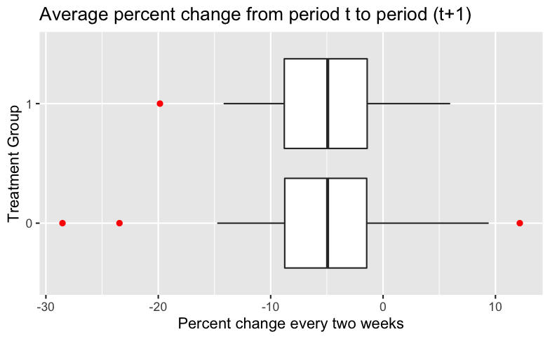

```r
# Construct boxplots of percent delcines for patients in each treatment group
spec.treat <- unique(subset(epilepsy[order(epilepsy$patient),],
                            select=c("patient","treat")))
peff <- coef(fit4)$patient
spec.effect <- data.frame(rownames(peff),spec.treat$treat,
                          100*(exp(peff$period)-1))
colnames(spec.effect) <- c("patient","treat","change")
spec.effect$treat <- as.factor(spec.effect$treat)
bp <- ggplot(spec.effect, aes(treat,change))+
             geom_boxplot(outlier.color = "Red") + coord_flip()
print(bp + labs(title = "Average percent change from period t to period (t+1)",
                x = "Treatment Group", y ="Percent change every two weeks"))
```

For majority patients in both treatment groups, the percent change ranges from a little over a 15% decline to just under a 10% increase in seizures every 2 weeks.

### Deviance Residual Plots

```r
# Construct residual plots
fv <- fitted(fit4)
resid <- residuals(fit4)
layout(matrix(1:4,c(2,2), byrow = TRUE))

# Histogram of Residuals
hist(resid, xlab = "Residuals", prob = TRUE, col = "grey", main = NULL)
curve(dnorm(x, mean = mean(resid), sd = sqrt(var(resid))), add = TRUE,
      col = "darkblue", lwd = 2)
```

```r
# Boxplot of residuals
boxplot(resid, col = "grey", ylab = "Residuals")

# Q-Q plot of residuals
qqnorm(resid, ylab = "Residuals", pch = 20, main = NULL)
```

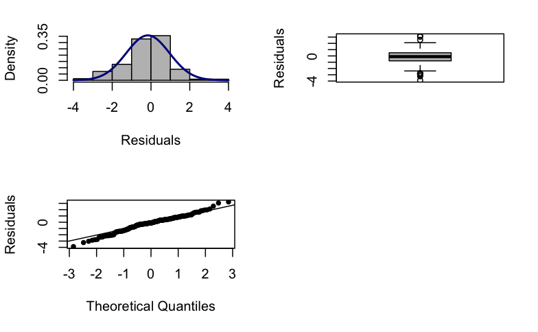

```r
qqline(resid)

# Residuals vs fitted values
plot(fv, resid, pch = 20, xlab = "Fitted Values", ylab = "Residuals")
```

No violation of the assumed log-link and normality on pseudo-responses